# Project #1: The Relationship between Winning Party, Unemployment Rate, Poverty Rate, and Education Levels

Ching Yi Lam

9/16/2024

# 1 Introduction

The purpose of this project is to analysis 4 data sets: Presidential Election Data, Unemployment Data, Poverty Data, and Education Data. We combined those 4 data sets together to one data set and each county has only one record which is the winning party. Those 4 data sets are provided from the professor to do the analysis report.

We want to see if there is any relationship between the winning party, the unemployment rate, the poverty rate, and the education levels.

The first part of the project is data integration that we picked up specific data that we needed for doing the analysis. The second part of the project is to do an analysis for those data and create some statistical graphics to identify patterns and trends.

We will use SQL to clean up the data and R Markdown to write the report and show the graphics.

## 1.1 Data Integration

These are the information we included in the data set.

### 1.1.1 Presidential Election Data

We kept the 2020 election data out of all the different years. We have two major parties for this data: Democrats and Republicans. We aggregated the total votes and kept the winning party in the data. We also kept the county FIPS code, state name, county name, total votes received in the winning party and the name of the party.

### 1.1.3 Poverty Data

We kept the poverty rate for 2019 and the county FIPS code.

### 1.1.4 Education Data

We kept the percentage of 4 different education levels: less than a high school diploma, high school diploma, completed between 1 to 3 years of college, and completed four years of college between 2015 and 2019. We also kept the county FIPS code.

```r
Data <- read.csv("https://raw.githubusercontent.com/ChingyiLam/Project1/refs/heads/main/data.csv", stringsAsFactors = TRUE)
```

# 2 Exploratory Data Analysis

## 2.1 Summary of Data

Year is the year of the election data.

County_fips is specific number for different county in different state.

State is different states in the United States.

County_name is the name of the county in the states.

Candidatevotes is the amount of people voted for that candidate.

Totalvotes is the total number of vote that people voted.

Party is the winning party of Democrat or Republican.

Poverty_rate is the poverty rate in 2019

No_high_school is the percentage of people who has education less than a high school diploma.

High_school_only is the percentage of people who has a high school diploma.

Some_college is the percentage of people who completed between 1 to 3 years of college.

Bachelor is the percentage of people who completed four years of college.

```r
summary(Data)
```

```
      year       county_fips         state          county_name
 Min.   :2020   Min.   : 1001   TEXAS   : 254   WASHINGTON:  32
 1st Qu.:2020   1st Qu.:18174   GEORGIA : 159   JEFFERSON :  26
 Median :2020   Median :29195   VIRGINIA: 133   FRANKLIN  :  25
 Mean   :2020   Mean   :30436   KENTUCKY: 120   JACKSON   :  24
 3rd Qu.:2020   3rd Qu.:46026   MISSOURI: 116   LINCOLN   :  24
 Max.   :2020   Max.   :56045   (Other) :2401   (Other)   :3052
 NA's   :406    NA's   :406     NA's    : 406   NA's      : 406
 candidatevotes      totalvotes             party      Unemployment_rate
 Min.   :      0   Min.   :     66   DEMOCRAT  : 880   Min.   : 0.800
 1st Qu.:   2162   1st Qu.:   5376   REPUBLICAN:2303   1st Qu.: 3.000
 Median :   6179   Median :  12290   NA's      : 406   Median : 3.700
 Mean   :  27376   Mean   :  49906                     Mean   : 4.081
 3rd Qu.:  17161   3rd Qu.:  33076                     3rd Qu.: 4.600
 Max.   :3028885   Max.   :4264365                     Max.   :20.900
 NA's   :406       NA's   :407                         NA's   :287
  Poverty_rate   No_high_school  High_school_only  Some_college
 Min.   : 2.70   Min.   : 1.10   Min.   : 7.30    Min.   : 5.20
 1st Qu.:10.40   1st Qu.: 8.50   1st Qu.:29.30    1st Qu.:27.00
 Median :13.30   Median :11.80   Median :34.20    Median :30.70
 Mean   :14.38   Mean   :13.29   Mean   :33.92    Mean   :30.64
 3rd Qu.:17.30   3rd Qu.:17.00   3rd Qu.:38.90    3rd Qu.:34.20
 Max.   :47.70   Max.   :73.60   Max.   :57.40    Max.   :60.60
 NA's   :366     NA's   :286     NA's   :286      NA's   :286
    Bachelor
 Min.   : 0.00
 1st Qu.:15.50
 Median :19.80
 Mean   :22.15
 3rd Qu.:26.40
 Max.   :77.60
 NA's   :286
```

```r
data2 = na.omit(Data)
```

In the summary below, we removed the missing value from the data.

```r
summary(data2)
```

```
      year       county_fips         state          county_name
 Min.   :2020   Min.   : 1001   TEXAS   : 254   WASHINGTON:  32
 1st Qu.:2020   1st Qu.:19048   GEORGIA : 159   JEFFERSON :  26
 Median :2020   Median :30001   VIRGINIA: 133   FRANKLIN  :  25
 Mean   :2020   Mean   :30783   KENTUCKY: 120   JACKSON   :  24
 3rd Qu.:2020   3rd Qu.:46044   MISSOURI: 116   LINCOLN   :  24
 Max.   :2020   Max.   :56045   KANSAS  : 105   MADISON   :  20
                                (Other) :2256   (Other)   :2992
 candidatevotes      totalvotes             party      Unemployment_rate
 Min.   :      0   Min.   :     66   DEMOCRAT  : 860   Min.   : 0.800
 1st Qu.:   2135   1st Qu.:   5348   REPUBLICAN:2283   1st Qu.: 3.000
 Median :   6227   Median :  12496                     Median : 3.700
 Mean   :  27610   Mean   :  50417                     Mean   : 3.907
 3rd Qu.:  17491   3rd Qu.:  33560                     3rd Qu.: 4.500
 Max.   :3028885   Max.   :4264365                     Max.   :20.900

  Poverty_rate   No_high_school  High_school_only  Some_college
 Min.   : 2.70   Min.   : 1.10   Min.   : 7.30    Min.   : 5.20
 1st Qu.:10.40   1st Qu.: 8.40   1st Qu.:29.60    1st Qu.:27.30
 Median :13.40   Median :11.70   Median :34.50    Median :30.80
 Mean   :14.42   Mean   :13.03   Mean   :34.11    Mean   :30.86
 3rd Qu.:17.40   3rd Qu.:16.60   3rd Qu.:39.10    3rd Qu.:34.30
 Max.   :47.70   Max.   :73.60   Max.   :57.40    Max.   :60.60

    Bachelor
 Min.   : 0.00
 1st Qu.:15.40
 Median :19.60
 Mean   :21.99
 3rd Qu.:26.00
 Max.   :77.60
```

### 2.1.1 Summary of Categorical Data

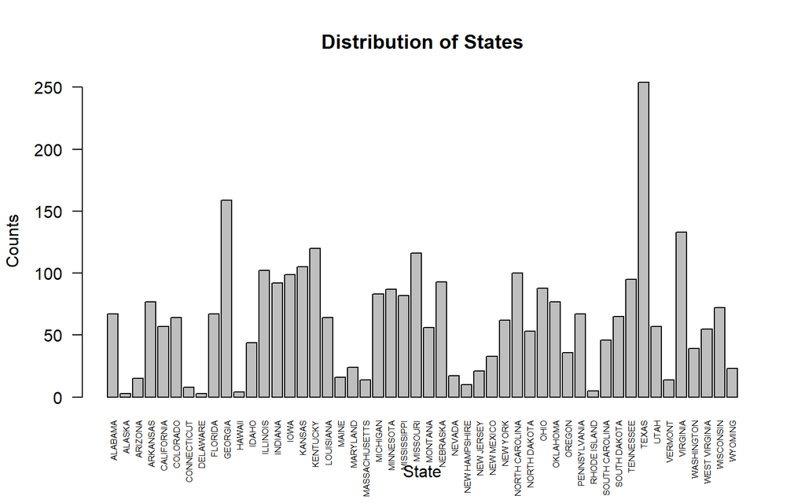

```r
par(mfrow=c(1,1))
freq.tbl_1 = table(data2$state)
barplot(freq.tbl_1, xlab="State", ylab = "Counts", main="Distribution of States", las = 2, cex.names = 0.5)
```

The bar plot is to show the distribution of the states with counts.

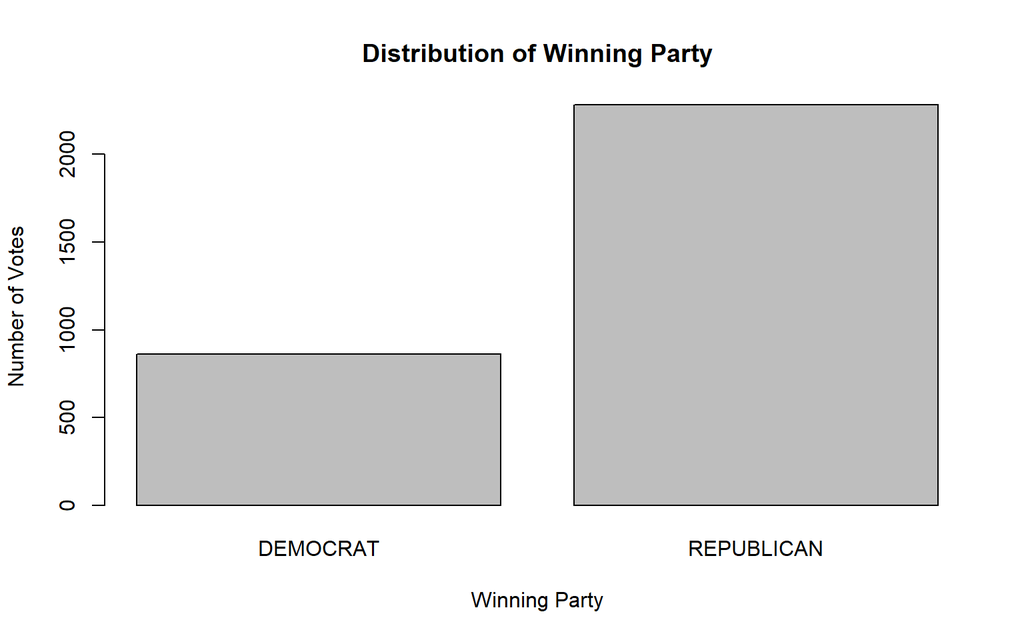

```r
par(mfrow=c(1,1))
freq.tbl_2 = table(data2$party)
barplot(freq.tbl_2, xlab="Winning Party", ylab = "Number of Votes", main="Distribution of Winning Party")
```

### 2.1.2 Summary of Numerical Data

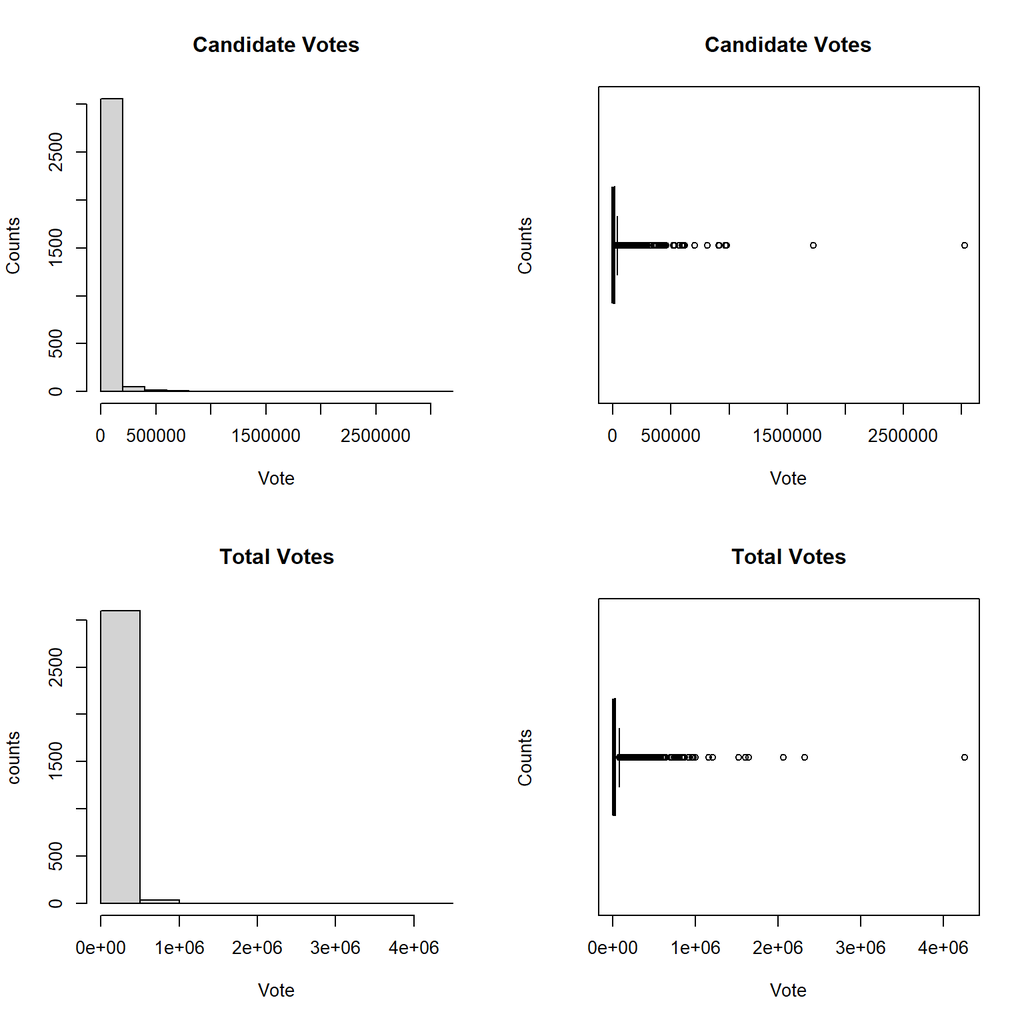

```r
par(mfrow = c(2,2))
hist(data2$candidatevotes, xlab = "Vote", ylab = "Counts", main = "Candidate Votes")
boxplot(data2$candidatevotes, xlab = "Vote", ylab = "Counts", main = "Candidate Votes", horizontal = TRUE)
hist(data2$totalvotes, xlab = "Vote", ylab = "counts", main = "Total Votes")
boxplot(data2$totalvotes, xlab = "Vote", ylab = "Counts", main = "Total Votes", horizontal = TRUE)
```

[figure not shown]

```r
den1 = density(data2$Unemployment_rate)
plot(den1, xlab = "Unemployment Rate", ylab = "Percentage", main = "Unemployment Rate")
den2 = density(data2$Poverty_rate)
plot(den1, xlab = "Poverty Rate", ylab = "Percentage", main = "Poverty Rate")
boxplot(data2$No_high_school, xlab = "Education Level Less Than a High School Diploma", ylab = "Percentage", main = "Education Level Less Than a High School Diploma")
boxplot(data2$High_school_only, xlab = "Education Level With a High School Diploma", ylab = "Percentage", main = "Education Level With a High School Diploma")
```

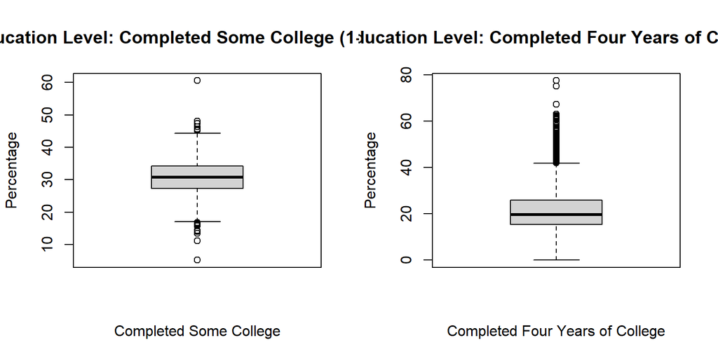

```r
par(mfrow = c(1,2))
boxplot(data2$Some_college, xlab = "Completed Some College", ylab = "Percentage", main = "Education Level: Completed Some College (1-3 years")
boxplot(data2$Bachelor, xlab = "Completed Four Years of College", ylab = "Percentage", main = "Education Level: Completed Four Years of College")
```

We have histogram and box plot for both candidate votes and total votes. We can see that there are a lot of outliers. Both the candidate votes and the total votes are heavily skewed to the right. After checked the data, we found out that some of the county in some of the states have a big population so the amount of people who voted in the county that is higher such as Los Angeles in California has 3028885 candidate votes and 4264365 total votes while Sierra in California only has 1142 candidate votes and 1931 total votes.

When we looked at the box plot for education level less than high school diploma, education level with a high school diploma, completed between 1 to 3 years of college and completed four years of college, we can see that there is more percentage of people has a high school diploma.

## 2.2 Two Variables

### 2.2.1 Unemployment Rate and Poverty Rate

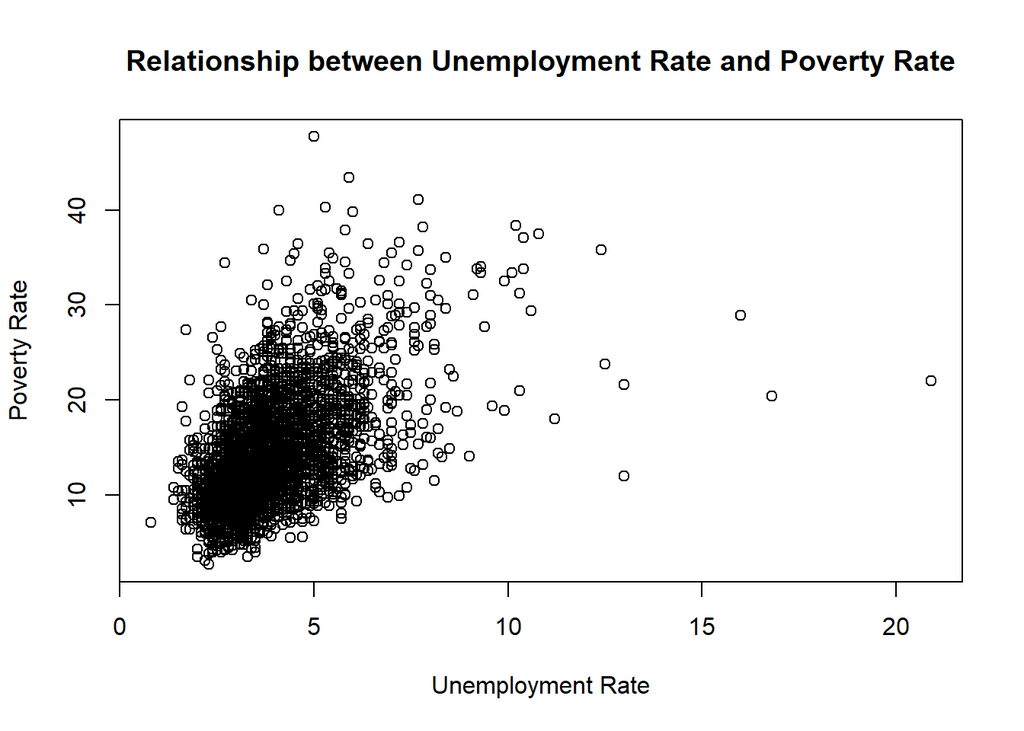

```r
plot(data2$Unemployment_rate, data2$Poverty_rate, xlab = "Unemployment Rate", ylab = "Poverty Rate", main = "Relationship between Unemployment Rate and Poverty Rate")
```

The above scatter plot indicates a linear trend between the unemployment rate and poverty rate.

### 2.2.2 Poverty Rate and Education Levels

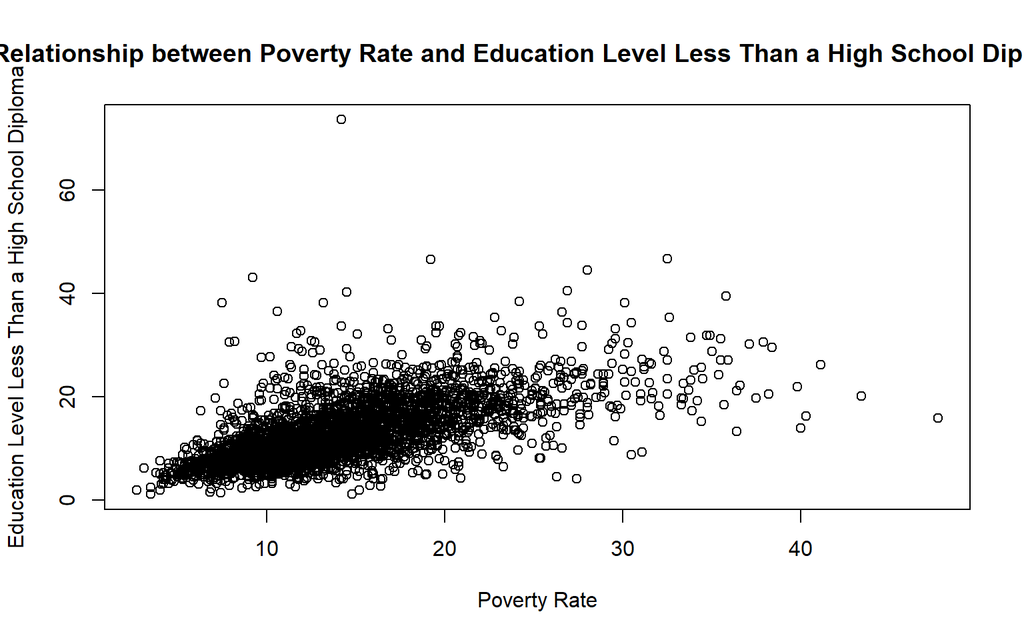

```r
par(mfrow = c(1,1))
plot(data2$Poverty_rate, data2$No_high_school, xlab = "Poverty Rate", ylab = "Education Level Less Than a High School Diploma", main = "Relationship between Poverty Rate and Education Level Less Than a High School Diploma")
```

The above scatter plot indicates a positive linear trend between the poverty rate and percentage of education level less than a high school diploma.

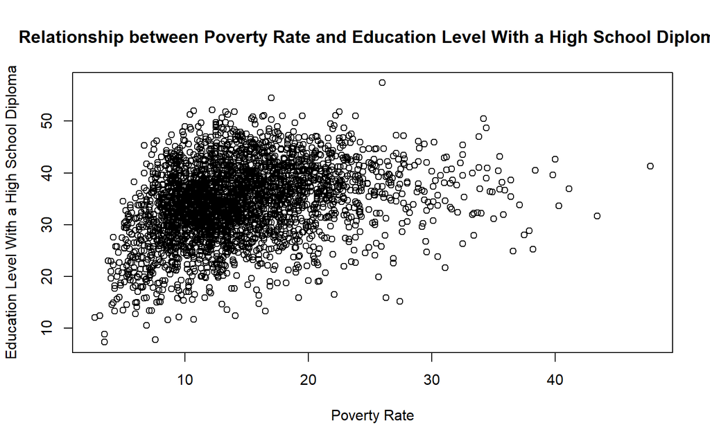

```r
par(mfrow = c(1,1))
plot(data2$Poverty_rate, data2$High_school_only, xlab = "Poverty Rate", ylab = "Education Level With a High School Diploma", main = "Relationship between Poverty Rate and Education Level With a High School Diploma")
```

The above scatter plot indicates a weak positive linear trend between the poverty rate and percentage of education level with a high school diploma.

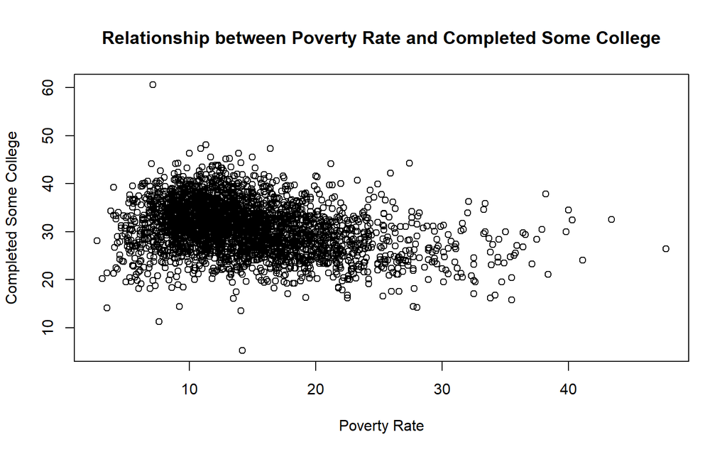

```r
par(mfrow = c(1,1))
plot(data2$Poverty_rate, data2$Some_college, xlab = "Poverty Rate", ylab = "Completed Some College", main = "Relationship between Poverty Rate and Completed Some College")
```

The above scatter plot indicates a weak negative linear trend between the poverty rate and percentage of people completed between 1 to 3 years of college.

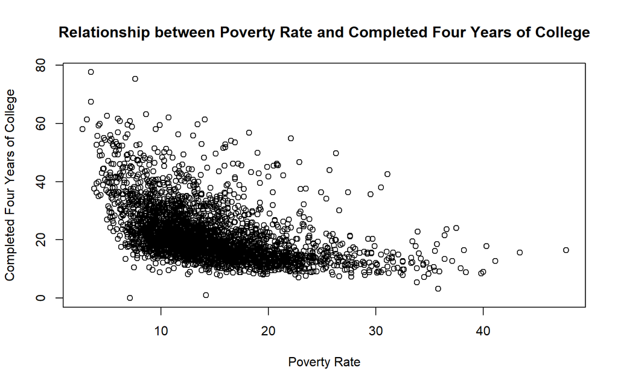

```r
par(mfrow = c(1,1))
plot(data2$Poverty_rate, data2$Bachelor, xlab = "Poverty Rate", ylab = "Completed Four Years of College", main = "Relationship between Poverty Rate and Completed Four Years of College")
```

The above scatter plot indicates a negatively correlated trend between the poverty rate and percentage of people completed four years of college.

### 2.2.3 Winning Party and Unemployment Rate

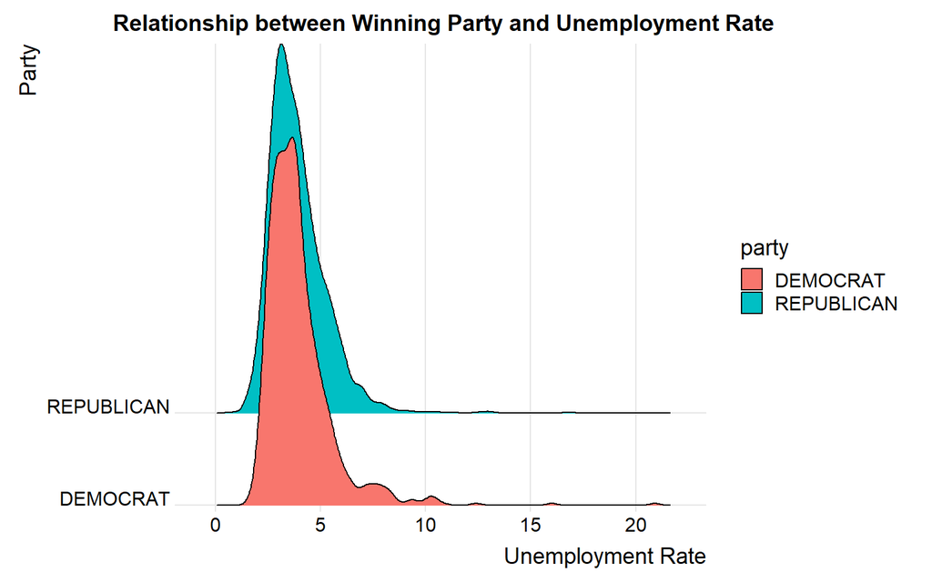

Ridge plot of Relationship between Party and Unemployment Rate.

```r
ggplot(data2, aes(x=Unemployment_rate, y=party, fill=party))+
   geom_density_ridges_gradient(scale = 4) + theme_ridges() +
    scale_y_discrete(expand = c(0.01, 0)) +
  scale_x_continuous(expand = c(0.08, 0)) +
  labs(x = "Unemployment Rate",y = "Party") +
  ggtitle("Relationship between Winning Party and Unemployment Rate") +
  theme(plot.title = element_text(hjust = 0.5))
```

From the graph above we can see that the trend of the relationship between the winning parties and the unemployment rate is similar. This means that the winning party has no clear effect on the unemployment rate.

# 3 Result

## 3.1 Further Research

It will be interesting to have a linear regression model between the poverty rate and the education levels because as we can see if the people has lower education level, the poverty rate increased. They have a positive linear relationship. However, as the education level increased, the relationship between the poverty rate and the education level is negatively correlated. For doing some of the regression models such as running ANOVA model will be able to confirm our observation of the pattern.

# 4 Appendix

election <- read.csv(“https://pengdsci.github.io/datasets/countypresidential_election_2000-2020.csv”) unemployment <- read.csv(“https://pengdsci.github.io/datasets/Unemployment.csv”) poverty <- read.csv(“https://pengdsci.github.io/datasets/PovertyEstimates.csv”) education <- read.csv(“https://raw.githubusercontent.com/ChingyiLam/Project1/refs/heads/main/Education.csv”)

summary(election) summary(unemployment) summary(poverty) summary(education)

con <- dbConnect(drv = SQLite(), dbname = “:memory:”)

dbWriteTable(conn = con, name = “election”, value = election)

dbWriteTable(conn = con, name = “unemployment”, value = unemployment)

dbWriteTable(conn = con, name = “poverty”, value = poverty)

dbWriteTable(conn = con, name = “education”, value = education)

rm(election, unemployment, poverty, education)

tbl(src = con,  
“election”)  
tbl(src = con, “unemployment”) tbl(src = con, “poverty”) tbl(src = con, “education”)

SELECT year, county_fips, state, county_name, candidatevotes, totalvotes, party FROM election WHERE year = 2020 AND party in (‘DEMOCRAT’, ‘REPUBLICAN’) GROUP BY county_fips, state, county_name, party ORDER BY county_fips, candidatevotes DESC;

SELECT year, county_fips, state, county_name, candidatevotes, totalvotes, party FROM election_new AS e WHERE candidatevotes = ( SELECT MAX(candidatevotes) FROM election_new AS sub_e WHERE sub_e.county_fips = e.county_fips );

SELECT FIPS_code, Attribute, value FROM unemployment WHERE Attribute = “Unemployment_rate_2019” GROUP BY FIPS_Code, value;

SELECT FIPStxt, Attribute, value FROM poverty WHERE Attribute = “PCTPOVALL_2019” GROUP BY FIPStxt, value;

SELECT FIPS, No_high_school, High_school_only, Some_college, Bachelor FROM education GROUP BY FIPS;

dbWriteTable(conn = con, name = “election_new”, value = election_new)

dbWriteTable(conn = con, name = “election_del”, value = election_del)

dbWriteTable(conn = con, name = “unemployment_new”, value = unemployment_new)

dbWriteTable(conn = con, name = “poverty_new”, value = poverty_new)

dbWriteTable(conn = con, name = “education_new”, value = education_new)

SELECT A.year, A.county_fips, A.state, A.county_name, A.candidatevotes, A.totalvotes, A.party, B.value, C.value, D.No_high_school, D.High_school_only, D.Some_college, D.Bachelor FROM election_del AS A FULL JOIN unemployment_new AS B ON A.county_fips = B.FIPS_Code FULL JOIN poverty_new AS C ON A.county_fips = C.fipstxt AND B.fips_code = C.fipstxt FULL JOIN education_new AS D ON A.county_fips = D.FIPS AND B.FIPS_Code = D.FIPS AND C.fipstxt = D.FIPS;

dbWriteTable(conn = con, name = “data”, value = data)

write.csv(data, “data.csv”, row.names = FALSE)